# SLAMming with Spheros

##### IPython Notebook

The complete coverage is available in at [Coverage](https://github.com/srinivaskandasamy/Coverage/tree/master/mayw3)

# Weekly Report

## Friday, May $8^{th}$, 2015

### Meeting with Tamas

1. To chart out a plan for the following weeks
2. Need a comparison between the NLSO (Nonlinear Least Squares Optimization)- offline method and FastSLAM (Factored Solution To SLAM)- online method
3. Comparison of wall looks at various levels of histogram (in the report)
4. Possibility of starting the histogram at the initial levels - Not possible
5. Need an explanation of preference of histogram filter over standard Gaussian filter
   - Achieving a mid-level in them
   - Faster and computationally easier over grid-based mapping
6. Computational issues related to the use of particle filters
   - Currently running into those problems (Need CUDA?)
   - Can be avoided by discounting the past measurements
   - Resampling only if needed (Adaptive particle filter-KLD sampling)
7. Measurements at start have lower values than future measurements
   - Effect of normalization at every step
8. Final wall scaling to 1 for a better colour scale
9. Comparison between official FastSLAM and my-FastSLAM
10. Comparison between the 2 versions of FastSLAM if time persists

## Monday, May $11^{th}$, 2015

### Working on the practical setup

1. Got the maze setup
2. Encoding reflective collisions
   - Need to consider the effect of previous measurements
   - New Heading = Old Heading + (d + 90 - alpha), where d is the desired reflection angle from the wall, alpha is the angle of collision - (atan(ax/ay)), ax and ay are the accelerometer values in the x and y direction
   - Adjust the heading from previous measurements - Yet to implement
     - Destabilize the robot
     - Adjust the heading, and
     - Stabilize the robot

## Tuesday, May $12^{th}$, 2015

### Encoding map information in histograms

1. Histogram features can give the same information over grid-based feature, but computationally faster
2. Encode the histogram data on the wall - Final feature initialization
3. Use Discrete Bayes filter to propagate the histogram distribution
4. Add the additional features such as clubbing of close collisions and trajectory-based pruning

## Wednesday, May $13^{th}$, 2015

### Space institute work (with Frank)

1. Worked on simultaneous operation of multiple Spheros
   - Best to go with 3
   - Facing bluetooth issues - Loses connection in the middle
   - Odometry error at higher speeds or large impacts
2. Simple roomba program
   - Done by Frank

## Thursday, May $14^{th}$, 2015

### Using histogram information in SLAM

1. A separate histogram initialized for every wall
2. Each wall or landmark contains several features
   - Each face of the wall represents the feature, given by box constraints
3. Each wall with features is encoded in a tree data structure, along with the histogram data for faster (logarithmic) feature search
4. Pointer-based feature search and histogram storage for higher computaional efficiency and search (All turns logarithmic)

### Pruning histogram data using trajectory information

1. Taking the collision information into the histogram pruning information
2. Pruning the wall data present in the convex combination of the consecutive measurements

## Friday, May $15^{th}$, 2015

### Offline SLAM using the FastSLAM algorithm

1. Use the measurements from the recorded data in simulation
2. With the presence of continuous set of measurements, the prediction step in the problem is no longer required
3. Maximum likelihood correspondence is enough for particle filters since data association decisions are made on per-particle basis

## Offline SLAM

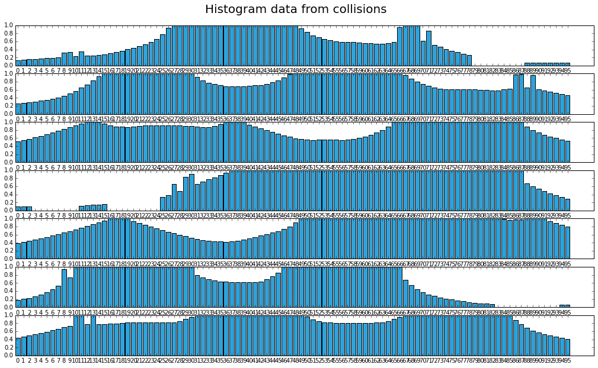

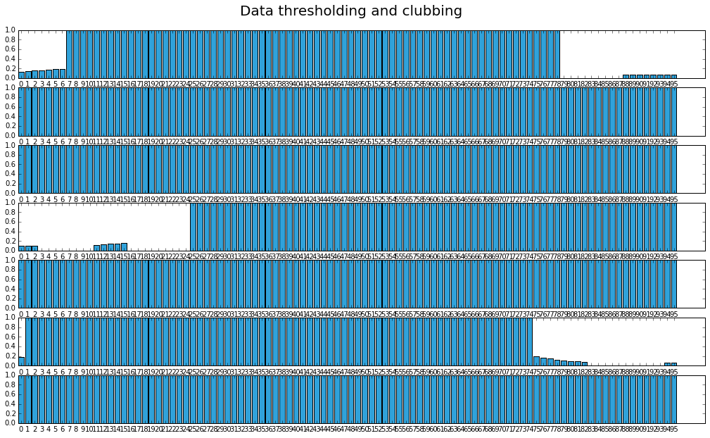

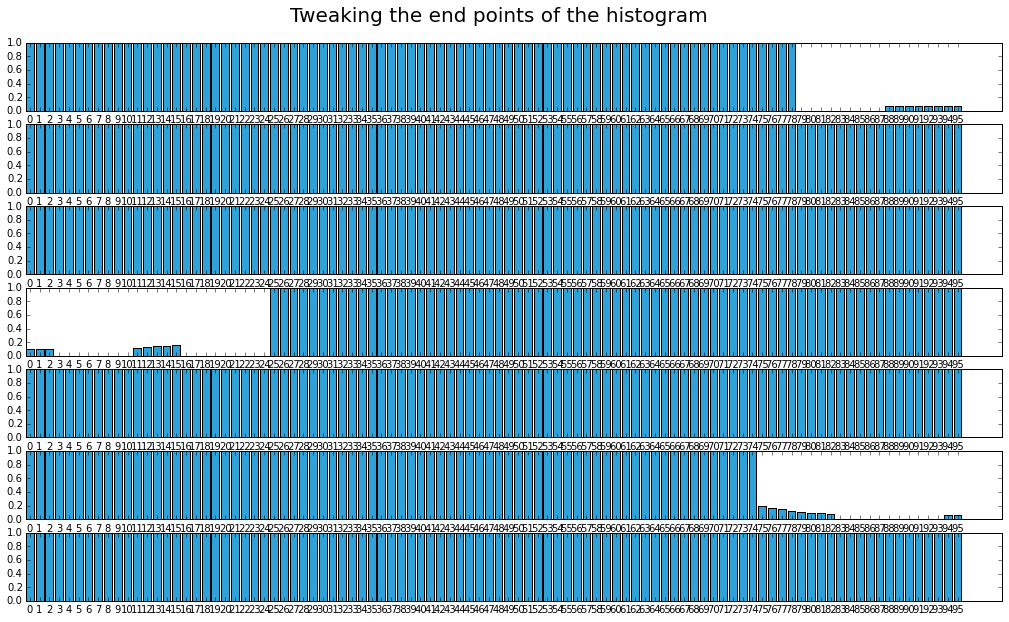

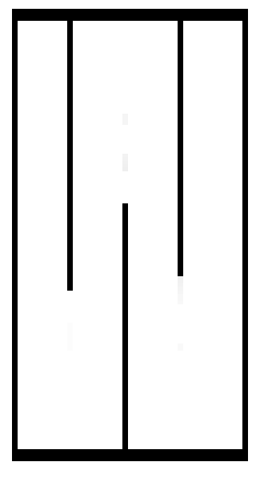

```python
# Offline SLAM
%run slam.ipynb
```

## Monday, May $18^{th}$, 2015

### Online SLAM - myFastSLAM

1. Adapting the offline SLAM problem to an online version
2. Adapting the discretization of the histogram
3. Modifying the pruning of the histogram to the correction step
4. Decide when to do data thresholding, tweaking and clubbing of landmarks
   - Stop the robot at certain point and process the data
   - A more rich map can be obtained similar to offline SLAM
5. Faced some computational issues with map update as well as when particle size increases
   - Update the corresponding histogram only when needed
   - Renormalize the histogram at certain points (Can give the effect of multiple measurements)

```python
# Online myFastSLAM
%run ball_in_the_lab.ipynb
```

```
[[[0, 0, 0], [1, 1, 1], [2, 2, 2], [3, 3, 3]], []]
```